# Project: Investigate a Dataset - [TMDb movie data]

- Introduction
- Data Wrangling
- Exploratory Data Analysis
- Conclusions

## Introduction

### Dataset Description

This data set contains information about 10,000 movies collected from The Movie Database (TMDb), including user ratings and revenue.

It consists of 21 columns ('id', 'imdb_id', 'popularity', 'budget', 'revenue', 'original_title','cast', 'homepage', 'director', 'tagline', 'keywords', 'overview','runtime', 'genres', 'production_companies', 'release_date','vote_count', 'vote_average', 'release_year', 'budget_adj','revenue_adj').

Certain columns, like ‘cast’ and ‘genres’, contain multiple values separated by pipe (|) characters.

### Question(s) for Analysis

1. What is the most popular genre
2. Is the movie revenue affected by popularity?
3. Is the movie revenue affected by budget?
4. Which genre generated the highest revenue?

```python
# Importing of pyhton packages
import numpy as np
import pandas as pd
import matplotlib.pyplot as plt
import seaborn as sns
%matplotlib inline
```

```python
# Upgrade pandas to use dataframe.explode() function.
!pip install --upgrade pandas==0.25.0
```

## Data Wrangling

In this section, the data is imported and its general properties are checked.

### General Properties

```python
# loading of data
df = pd.read_csv('tmdb-movies.csv')
df.head(2)
```

|  | id | imdb_id | popularity | budget | revenue | original_title | cast | homepage | director | tagline | ... | overview | runtime | genres | production_companies | release_date | vote_count | vote_average | release_year | budget_adj | revenue_adj |
| --- | --- | --- | --- | --- | --- | --- | --- | --- | --- | --- | --- | --- | --- | --- | --- | --- | --- | --- | --- | --- | --- |
| 0 | 135397 | tt0369610 | 32.985763 | 150000000 | 1513528810 | Jurassic World | Chris Pratt\|Bryce Dallas Howard\|Irrfan Khan\|Vi... | http://www.jurassicworld.com/ | Colin Trevorrow | The park is open. | ... | Twenty-two years after the events of Jurassic ... | 124 | Action\|Adventure\|Science Fiction\|Thriller | Universal Studios\|Amblin Entertainment\|Legenda... | 6/9/15 | 5562 | 6.5 | 2015 | 1.379999e+08 | 1.392446e+09 |
| 1 | 76341 | tt1392190 | 28.419936 | 150000000 | 378436354 | Mad Max: Fury Road | Tom Hardy\|Charlize Theron\|Hugh Keays-Byrne\|Nic... | http://www.madmaxmovie.com/ | George Miller | What a Lovely Day. | ... | An apocalyptic story set in the furthest reach... | 120 | Action\|Adventure\|Science Fiction\|Thriller | Village Roadshow Pictures\|Kennedy Miller Produ... | 5/13/15 | 6185 | 7.1 | 2015 | 1.379999e+08 | 3.481613e+08 |

2 rows × 21 columns

```python
#shape of dataset
df.shape
```

```
(10866, 21)
```

```python
#types of data in the dataset
df.dtypes
```

```
id                        int64
imdb_id                  object
popularity              float64
budget                    int64
revenue                   int64
original_title           object
cast                     object
homepage                 object
director                 object
tagline                  object
keywords                 object
overview                 object
runtime                   int64
genres                   object
production_companies     object
release_date             object
vote_count                int64
vote_average            float64
release_year              int64
budget_adj              float64
revenue_adj             float64
dtype: object
```

```python
#information on dataset
#we can know if there are missing values
df.info()
```

```
<class 'pandas.core.frame.DataFrame'>
RangeIndex: 10866 entries, 0 to 10865
Data columns (total 21 columns):
 #   Column                Non-Null Count  Dtype
---  ------                --------------  -----
 0   id                    10866 non-null  int64
 1   imdb_id               10856 non-null  object
 2   popularity            10866 non-null  float64
 3   budget                10866 non-null  int64
 4   revenue               10866 non-null  int64
 5   original_title        10866 non-null  object
 6   cast                  10790 non-null  object
 7   homepage              2936 non-null   object
 8   director              10822 non-null  object
 9   tagline               8042 non-null   object
 10  keywords              9373 non-null   object
 11  overview              10862 non-null  object
 12  runtime               10866 non-null  int64
 13  genres                10843 non-null  object
 14  production_companies  9836 non-null   object
 15  release_date          10866 non-null  object
 16  vote_count            10866 non-null  int64
 17  vote_average          10866 non-null  float64
 18  release_year          10866 non-null  int64
 19  budget_adj            10866 non-null  float64
 20  revenue_adj           10866 non-null  float64
dtypes: float64(4), int64(6), object(11)
memory usage: 1.7+ MB
```

```python
#summary of the data
df.describe()
```

|  | id | popularity | budget | revenue | runtime | vote_count | vote_average | release_year | budget_adj | revenue_adj |
| --- | --- | --- | --- | --- | --- | --- | --- | --- | --- | --- |
| count | 10866.000000 | 10866.000000 | 1.086600e+04 | 1.086600e+04 | 10866.000000 | 10866.000000 | 10866.000000 | 10866.000000 | 1.086600e+04 | 1.086600e+04 |
| mean | 66064.177434 | 0.646441 | 1.462570e+07 | 3.982332e+07 | 102.070863 | 217.389748 | 5.974922 | 2001.322658 | 1.755104e+07 | 5.136436e+07 |
| std | 92130.136561 | 1.000185 | 3.091321e+07 | 1.170035e+08 | 31.381405 | 575.619058 | 0.935142 | 12.812941 | 3.430616e+07 | 1.446325e+08 |
| min | 5.000000 | 0.000065 | 0.000000e+00 | 0.000000e+00 | 0.000000 | 10.000000 | 1.500000 | 1960.000000 | 0.000000e+00 | 0.000000e+00 |
| 25% | 10596.250000 | 0.207583 | 0.000000e+00 | 0.000000e+00 | 90.000000 | 17.000000 | 5.400000 | 1995.000000 | 0.000000e+00 | 0.000000e+00 |
| 50% | 20669.000000 | 0.383856 | 0.000000e+00 | 0.000000e+00 | 99.000000 | 38.000000 | 6.000000 | 2006.000000 | 0.000000e+00 | 0.000000e+00 |
| 75% | 75610.000000 | 0.713817 | 1.500000e+07 | 2.400000e+07 | 111.000000 | 145.750000 | 6.600000 | 2011.000000 | 2.085325e+07 | 3.369710e+07 |
| max | 417859.000000 | 32.985763 | 4.250000e+08 | 2.781506e+09 | 900.000000 | 9767.000000 | 9.200000 | 2015.000000 | 4.250000e+08 | 2.827124e+09 |

```python
#non-unique datatypes
df.nunique()
```

```
id                      10865
imdb_id                 10855
popularity              10814
budget                    557
revenue                  4702
original_title          10571
cast                    10719
homepage                 2896
director                 5067
tagline                  7997
keywords                 8804
overview                10847
runtime                   247
genres                   2039
production_companies     7445
release_date             5909
vote_count               1289
vote_average               72
release_year               56
budget_adj               2614
revenue_adj              4840
dtype: int64
```

```python
#missing values
df.isnull().sum()
```

```
id                         0
imdb_id                   10
popularity                 0
budget                     0
revenue                    0
original_title             0
cast                      76
homepage                7930
director                  44
tagline                 2824
keywords                1493
overview                   4
runtime                    0
genres                    23
production_companies    1030
release_date               0
vote_count                 0
vote_average               0
release_year               0
budget_adj                 0
revenue_adj                0
dtype: int64
```

```python
#number of duplicates
df[df.duplicated()]
```

|  | id | imdb_id | popularity | budget | revenue | original_title | cast | homepage | director | tagline | ... | overview | runtime | genres | production_companies | release_date | vote_count | vote_average | release_year | budget_adj | revenue_adj |
| --- | --- | --- | --- | --- | --- | --- | --- | --- | --- | --- | --- | --- | --- | --- | --- | --- | --- | --- | --- | --- | --- |
| 2090 | 42194 | tt0411951 | 0.59643 | 30000000 | 967000 | TEKKEN | Jon Foo\|Kelly Overton\|Cary-Hiroyuki Tagawa\|Ian... | NaN | Dwight H. Little | Survival is no game | ... | In the year of 2039, after World Wars destroy ... | 92 | Crime\|Drama\|Action\|Thriller\|Science Fiction | Namco\|Light Song Films | 3/20/10 | 110 | 5.0 | 2010 | 30000000.0 | 967000.0 |

1 rows × 21 columns

```python
df.describe()
```

|  | id | popularity | budget | revenue | runtime | vote_count | vote_average | release_year | budget_adj | revenue_adj |
| --- | --- | --- | --- | --- | --- | --- | --- | --- | --- | --- |
| count | 10866.000000 | 10866.000000 | 1.086600e+04 | 1.086600e+04 | 10866.000000 | 10866.000000 | 10866.000000 | 10866.000000 | 1.086600e+04 | 1.086600e+04 |
| mean | 66064.177434 | 0.646441 | 1.462570e+07 | 3.982332e+07 | 102.070863 | 217.389748 | 5.974922 | 2001.322658 | 1.755104e+07 | 5.136436e+07 |
| std | 92130.136561 | 1.000185 | 3.091321e+07 | 1.170035e+08 | 31.381405 | 575.619058 | 0.935142 | 12.812941 | 3.430616e+07 | 1.446325e+08 |
| min | 5.000000 | 0.000065 | 0.000000e+00 | 0.000000e+00 | 0.000000 | 10.000000 | 1.500000 | 1960.000000 | 0.000000e+00 | 0.000000e+00 |
| 25% | 10596.250000 | 0.207583 | 0.000000e+00 | 0.000000e+00 | 90.000000 | 17.000000 | 5.400000 | 1995.000000 | 0.000000e+00 | 0.000000e+00 |
| 50% | 20669.000000 | 0.383856 | 0.000000e+00 | 0.000000e+00 | 99.000000 | 38.000000 | 6.000000 | 2006.000000 | 0.000000e+00 | 0.000000e+00 |
| 75% | 75610.000000 | 0.713817 | 1.500000e+07 | 2.400000e+07 | 111.000000 | 145.750000 | 6.600000 | 2011.000000 | 2.085325e+07 | 3.369710e+07 |
| max | 417859.000000 | 32.985763 | 4.250000e+08 | 2.781506e+09 | 900.000000 | 9767.000000 | 9.200000 | 2015.000000 | 4.250000e+08 | 2.827124e+09 |

```python
#the columns in the dataset
df.columns
```

```
Index(['id', 'imdb_id', 'popularity', 'budget', 'revenue', 'original_title',
       'cast', 'homepage', 'director', 'tagline', 'keywords', 'overview',
       'runtime', 'genres', 'production_companies', 'release_date',
       'vote_count', 'vote_average', 'release_year', 'budget_adj',
       'revenue_adj'],
      dtype='object')
```

#### In this Data wrangling section:

1. The data contains some missing values and duplicates.
2. The data contains nunique values
3. The data requires data cleaning.

### Data Cleaning

In this section, the data will be cleaned

```python
# drop columns that are not neccesary
df.drop(['homepage','tagline','production_companies','keywords','overview','imdb_id','id','release_date'], inplace = True, axis = 1)
```

```python
#the remaining columns after the un-necessary ones have been dropped.
df.columns
```

```
Index(['popularity', 'budget', 'revenue', 'original_title', 'cast', 'director',
       'runtime', 'genres', 'vote_count', 'vote_average', 'release_year',
       'budget_adj', 'revenue_adj'],
      dtype='object')
```

```python
df.info()
```

```
<class 'pandas.core.frame.DataFrame'>
RangeIndex: 10866 entries, 0 to 10865
Data columns (total 13 columns):
 #   Column          Non-Null Count  Dtype
---  ------          --------------  -----
 0   popularity      10866 non-null  float64
 1   budget          10866 non-null  int64
 2   revenue         10866 non-null  int64
 3   original_title  10866 non-null  object
 4   cast            10790 non-null  object
 5   director        10822 non-null  object
 6   runtime         10866 non-null  int64
 7   genres          10843 non-null  object
 8   vote_count      10866 non-null  int64
 9   vote_average    10866 non-null  float64
 10  release_year    10866 non-null  int64
 11  budget_adj      10866 non-null  float64
 12  revenue_adj     10866 non-null  float64
dtypes: float64(4), int64(5), object(4)
memory usage: 1.1+ MB
```

```python
# drop the missing values
df.dropna(inplace = True)
```

```python
df.info()
```

```
<class 'pandas.core.frame.DataFrame'>
Int64Index: 10732 entries, 0 to 10865
Data columns (total 13 columns):
 #   Column          Non-Null Count  Dtype
---  ------          --------------  -----
 0   popularity      10732 non-null  float64
 1   budget          10732 non-null  int64
 2   revenue         10732 non-null  int64
 3   original_title  10732 non-null  object
 4   cast            10732 non-null  object
 5   director        10732 non-null  object
 6   runtime         10732 non-null  int64
 7   genres          10732 non-null  object
 8   vote_count      10732 non-null  int64
 9   vote_average    10732 non-null  float64
 10  release_year    10732 non-null  int64
 11  budget_adj      10732 non-null  float64
 12  revenue_adj     10732 non-null  float64
dtypes: float64(4), int64(5), object(4)
memory usage: 1.1+ MB
```

```python
#datatype of 'release_year'
df['release_year'].dtype
```

```
dtype('int64')
```

```python
#summary of the data after removal of missing values
df.describe()
```

|  | popularity | budget | revenue | runtime | vote_count | vote_average | release_year | budget_adj | revenue_adj |
| --- | --- | --- | --- | --- | --- | --- | --- | --- | --- |
| count | 10732.000000 | 1.073200e+04 | 1.073200e+04 | 10732.000000 | 10732.000000 | 10732.000000 | 10732.000000 | 1.073200e+04 | 1.073200e+04 |
| mean | 0.652609 | 1.480506e+07 | 4.031622e+07 | 102.467853 | 219.802739 | 5.964620 | 2001.260436 | 1.776644e+07 | 5.200147e+07 |
| std | 1.004757 | 3.106345e+07 | 1.176476e+08 | 30.492619 | 578.789325 | 0.930286 | 12.819831 | 3.446490e+07 | 1.454192e+08 |
| min | 0.000188 | 0.000000e+00 | 0.000000e+00 | 0.000000 | 10.000000 | 1.500000 | 1960.000000 | 0.000000e+00 | 0.000000e+00 |
| 25% | 0.210766 | 0.000000e+00 | 0.000000e+00 | 90.000000 | 17.000000 | 5.400000 | 1995.000000 | 0.000000e+00 | 0.000000e+00 |
| 50% | 0.387135 | 0.000000e+00 | 0.000000e+00 | 99.000000 | 39.000000 | 6.000000 | 2006.000000 | 0.000000e+00 | 0.000000e+00 |
| 75% | 0.720621 | 1.600000e+07 | 2.500000e+07 | 112.000000 | 148.000000 | 6.600000 | 2011.000000 | 2.111556e+07 | 3.470526e+07 |
| max | 32.985763 | 4.250000e+08 | 2.781506e+09 | 900.000000 | 9767.000000 | 9.200000 | 2015.000000 | 4.250000e+08 | 2.827124e+09 |

```python
#since 'budget', 'revenue', 'budget_adj', 'revenue_adj' all contains zeros
#we need to replace the zeros with their mean values
zero_cols = ['budget', 'revenue', 'budget_adj', 'revenue_adj']
for item in zero_cols:
    print(item, df[item].mean())
    df[item] = df[item].replace({0:df[item].mean()})
```

```
budget 14805062.129332837
revenue 40316220.714405514
budget_adj 17766443.29313785
revenue_adj 52001473.63828793
```

```python
df.info()
```

```
<class 'pandas.core.frame.DataFrame'>
Int64Index: 10732 entries, 0 to 10865
Data columns (total 13 columns):
 #   Column          Non-Null Count  Dtype
---  ------          --------------  -----
 0   popularity      10732 non-null  float64
 1   budget          10732 non-null  float64
 2   revenue         10732 non-null  float64
 3   original_title  10732 non-null  object
 4   cast            10732 non-null  object
 5   director        10732 non-null  object
 6   runtime         10732 non-null  int64
 7   genres          10732 non-null  object
 8   vote_count      10732 non-null  int64
 9   vote_average    10732 non-null  float64
 10  release_year    10732 non-null  int64
 11  budget_adj      10732 non-null  float64
 12  revenue_adj     10732 non-null  float64
dtypes: float64(6), int64(3), object(4)
memory usage: 1.1+ MB
```

```
array([[<AxesSubplot:title={'center':'popularity'}>,
        <AxesSubplot:title={'center':'budget'}>,
        <AxesSubplot:title={'center':'revenue'}>],
       [<AxesSubplot:title={'center':'runtime'}>,
        <AxesSubplot:title={'center':'vote_count'}>,
        <AxesSubplot:title={'center':'vote_average'}>],
       [<AxesSubplot:title={'center':'release_year'}>,
        <AxesSubplot:title={'center':'budget_adj'}>,
        <AxesSubplot:title={'center':'revenue_adj'}>]], dtype=object)
```

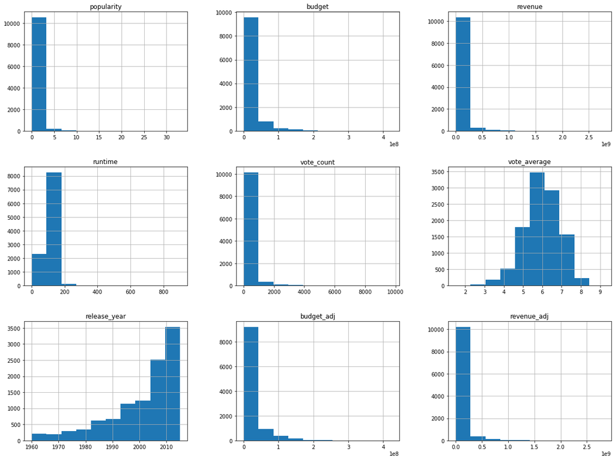

```python
#histogram overview of the dataset
df.hist(figsize = (20, 15))
```

```python
df.shape
```

```
(10732, 13)
```

```python
#Unique values in 'genres'
df['genres'].unique()
```

```
array(['Action|Adventure|Science Fiction|Thriller',
       'Adventure|Science Fiction|Thriller',
       'Action|Adventure|Science Fiction|Fantasy', ...,
       'Adventure|Drama|Action|Family|Foreign',
       'Comedy|Family|Mystery|Romance',
       'Mystery|Science Fiction|Thriller|Drama'], dtype=object)
```

```python
#designing a funtion that can split the 'genres' column
def seperate_values(col):
    new_cols=(df[col].str.split('|', expand=True).rename(columns=lambda x: f"{col}_{x+1}"))
    return new_cols
```

```python
#separating 'genres'
df_genres = seperate_values('genres')
```

```python
#separating 'cast'
df_cast = seperate_values('cast')
```

```python
#creating a duplicate for both 'genres' and 'cast'
df['cast'],df['genres']=df_cast['cast_1'],df_genres['genres_1']
```

```python
#checking if 'genres' have been splitted
df['genres'].unique()
```

```
array(['Action', 'Adventure', 'Western', 'Science Fiction', 'Drama',
       'Family', 'Comedy', 'Crime', 'Romance', 'War', 'Mystery',
       'Thriller', 'Fantasy', 'History', 'Animation', 'Horror', 'Music',
       'Documentary', 'TV Movie', 'Foreign'], dtype=object)
```

## Exploratory Data Analysis

### Research Question 1 (what is the most popular genre over the years?)

```python
#most popular genre over the years
bins_edges=[1960,1970,1980,1990,2000,2010,2015]
bins_names=['1960s','1970s','1980s','1990s','2000s','2010s']
df['release_year'] = pd.cut(df['release_year'], bins_edges, labels = bins_names)

df_year = df.groupby(["release_year","genres"])['popularity'].size().unstack()
```

```python
#grouping popularity by both 'release_year' and 'genres'
df_genres_by_year = df.groupby(["release_year","genres"])['popularity'].size().unstack()
```

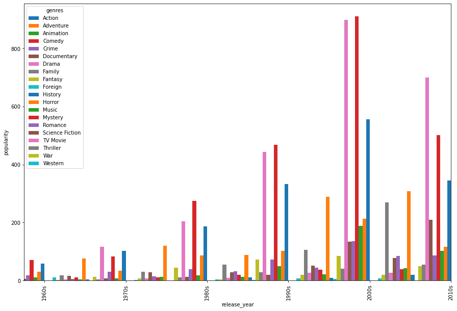

```python
#visualizing the most popular genre over the years

fig, ax = plt.subplots(figsize=(15,10))
df_genres_by_year.plot(kind='bar',ax=ax,width=-.9,align='edge');
ax.set_ylabel('popularity');
```

1. for 2010s: drama, comedy and action
2. for 2000s: comedy, drama and action
3. for 1990s: comedy, drama and action
4. for 1980s: comedy, drama and action
5. for 1970s: drama, action and comedy
6. for 1960s: comedy, action and adventure

### Research Question 2 (is the movie revenue affected by their popularity?)

```python
#correlation
corr_matrix = df[df['revenue'] != 0].corr()
```

```python
#correlation matrix
corr_matrix['revenue'].sort_values(ascending=False)
```

[output not shown]

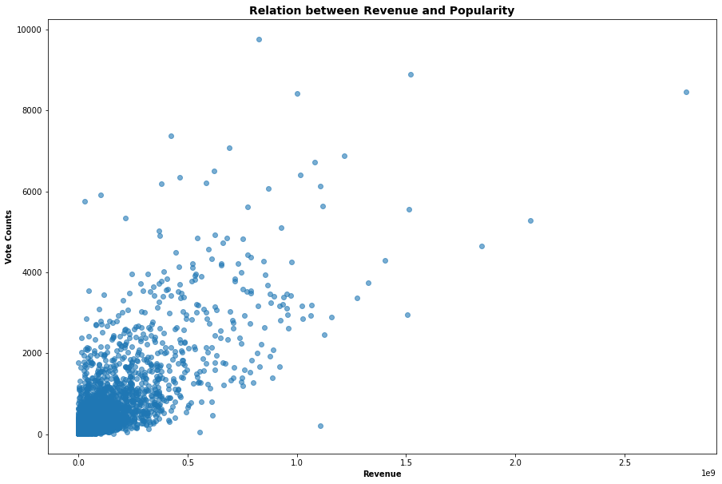

```python
# Plotting the relation between revenue & popularity of movies
plt.figure(figsize = (15, 10))
scatter_RP = plt.scatter(df['revenue'], df['vote_count'], alpha = 0.6)
plt.title("Relation between Revenue and Popularity", fontsize = 14, weight = "bold")
plt.xlabel("Revenue", weight = "bold")
plt.ylabel("Vote Counts", weight = "bold")
plt.show()
```

### From the scatter plot;

1. There is a positive correlation between revenue and popularity
2. The higher the revenue, the higher the popularity.

### Research Question 3 (is the movie revenue affected by budget?)

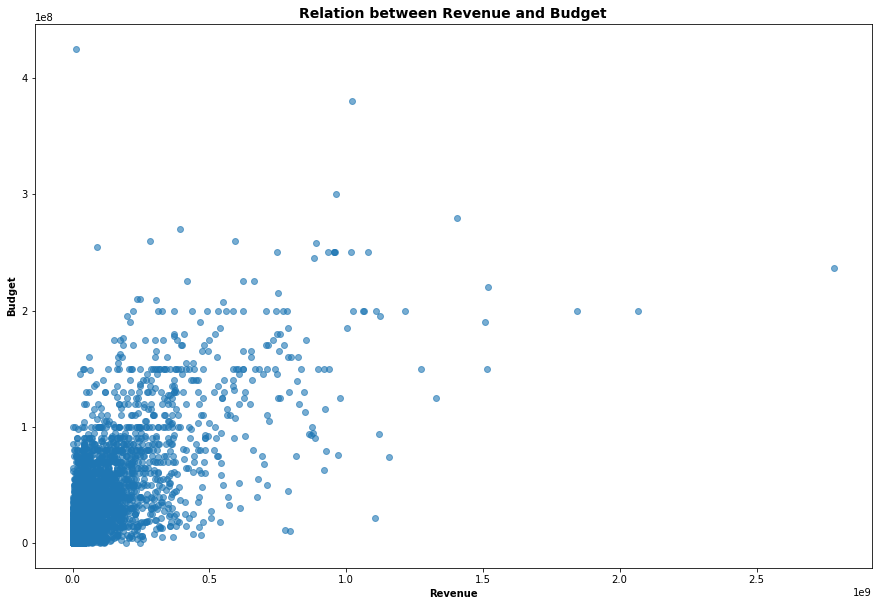

```python
# Plotting revenue against budget:
plt.figure(figsize = (15, 10))
scatter_RP = plt.scatter(df['revenue'],df['budget'], alpha = 0.6)
plt.title("Relation between Revenue and Budget", fontsize = 14, weight = "bold")
plt.xlabel("Revenue", weight = "bold")
plt.ylabel("Budget", weight = "bold")
plt.show()
```

### From the scatter plot:

1. There is a positive correlation between revenue and budget
2. Hence, the higher the budget, the higher the revenue.

### Research Question 4 (Which genre generated the highest revenue?)

```python
pd.pivot_table(df,index="release_year",columns="genres",values='revenue_adj',aggfunc=pd.Series.mean)
```

| genres release_year | Action | Adventure | Animation | Comedy | Crime | Documentary | Drama | Family | Fantasy | Foreign | History | Horror | Music | Mystery | Romance | Science Fiction | TV Movie | Thriller | War | Western |
| --- | --- | --- | --- | --- | --- | --- | --- | --- | --- | --- | --- | --- | --- | --- | --- | --- | --- | --- | --- | --- |
| 1960s | 9.680164e+07 | 2.126265e+08 | 7.570068e+07 | 8.055351e+07 | 8.259885e+07 | 5.200147e+07 | 1.084726e+08 | 3.753889e+08 | 5.200147e+07 | NaN | 3.870526e+08 | 5.697265e+07 | 1.873279e+08 | 5.704900e+07 | 5.200147e+07 | 9.536506e+07 | 5.200147e+07 | 5.200147e+07 | 5.442392e+07 | 7.451614e+07 |
| 1970s | 9.657102e+07 | 2.826259e+08 | 6.426026e+07 | 1.067412e+08 | 9.033312e+07 | 3.915221e+07 | 1.247652e+08 | 4.184791e+07 | 7.283883e+07 | NaN | 5.200147e+07 | 9.989670e+07 | 2.541636e+08 | 4.652145e+07 | 8.871735e+07 | 1.461195e+08 | 5.200147e+07 | 5.840903e+07 | 5.200147e+07 | 4.713168e+07 |
| 1980s | 7.277031e+07 | 1.597722e+08 | 7.235526e+07 | 7.085798e+07 | 5.105044e+07 | 4.072228e+07 | 7.806232e+07 | 7.255723e+07 | 1.289296e+08 | 5.200147e+07 | NaN | 5.212310e+07 | 4.377249e+07 | 4.251825e+07 | 9.822987e+07 | 1.461997e+08 | 5.200147e+07 | 5.737954e+07 | 4.722735e+07 | 5.200147e+07 |
| 1990s | 9.875282e+07 | 1.660686e+08 | 1.165118e+08 | 7.352392e+07 | 1.125080e+08 | 4.407131e+07 | 7.374246e+07 | 1.363279e+08 | 8.356606e+07 | 5.200147e+07 | 1.093272e+08 | 5.611461e+07 | 7.518525e+07 | 9.158545e+07 | 1.194028e+08 | 1.215061e+08 | 5.271121e+07 | 7.836991e+07 | 3.706758e+07 | 1.008347e+08 |
| 2000s | 8.970275e+07 | 2.065859e+08 | 1.131110e+08 | 6.340542e+07 | 5.651520e+07 | 4.041715e+07 | 5.707604e+07 | 1.183456e+08 | 1.309215e+08 | 5.200147e+07 | 1.241318e+08 | 5.853098e+07 | 6.890642e+07 | 6.423261e+07 | 7.043475e+07 | 1.023040e+08 | 5.200147e+07 | 8.393985e+07 | 8.659976e+07 | 7.888464e+07 |
| 2010s | 1.300969e+08 | 1.594933e+08 | 1.428752e+08 | 5.616066e+07 | 5.675618e+07 | 4.490089e+07 | 4.507053e+07 | 8.730162e+07 | 1.096148e+08 | NaN | 4.656956e+07 | 4.965674e+07 | 5.034744e+07 | 4.985033e+07 | 5.910595e+07 | 1.387729e+08 | 5.200147e+07 | 5.105806e+07 | 1.120268e+08 | 9.278971e+07 |

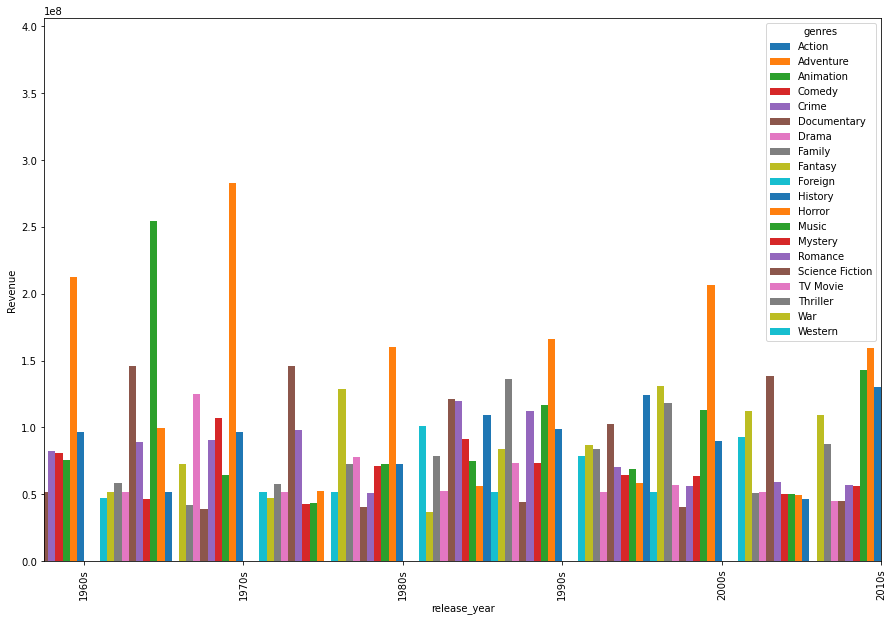

```python
fig, ax = plt.subplots(figsize=(15,10))
pd.pivot_table(df,index="release_year",columns="genres",values='revenue_adj',aggfunc=pd.Series.mean).\
plot(kind='bar',ax=ax,width=-.9,align='edge');
ax.set_ylabel('Revenue');
```

### The genre that generated the highest revenue is 'adventure'

## Limitations

1. After the dropping of some columns and the removal of the missing values, a small level of uncertainty have been introduced.
2. Due to the uncertainty, it is difficult to have a 100% correct predicition and analysis.

```python
from subprocess import call
call(['python', '-m', 'nbconvert', 'Investigate_a_Dataset.ipynb'])
```